# Практика · CNN цілком

> Лекція: lecture.html · Тест: quiz.html · Домашнє завдання: homework.html

У лекції ми зібрали згорткову мережу з блоків і порахували, що в ній де лежить. Тут кожне з тих чисел ти отримаєш сам — і звіриш ручний розрахунок із тим, що показує PyTorch.

Що зробимо:

**Мережа не потрібна:** датасет ми малюємо самі, формулами.

```python
import time
import numpy as np
import torch
import torch.nn as nn

# зерна фіксуємо на самому початку: без них числа нижче не збіжаться з лекцією
torch.manual_seed(0)
rng = np.random.default_rng(42)
torch.set_num_threads(4)

print("torch     :", torch.__version__)
print("numpy     :", np.__version__)
print("потоків CPU:", torch.get_num_threads())
```

```
torch     : 2.10.0+cpu
numpy     : 2.5.1
потоків CPU: 4
```

## 1 · Датасет: шість фігур, намальованих формулами

Кожне зображення — квадрат 28×28 із однією фігурою: коло, квадрат, ромб, кільце, хрест або трикутник. Центр трохи зсунутий, радіус трохи різний, зверху накладено шум. Усе це рахується з координат пікселя, тому датасет однаковий у всіх, хто запустить зошит із тим самим зерном.

```python
SHAPE_NAMES = ["коло", "квадрат", "ромб", "кільце", "хрест", "трикутник"]


def draw_shape(kind, rng, size=28, jitter=2, noise=0.10):
    """Малює одну фігуру заданого класу як масив 28×28 зі значеннями 0..1."""
    image = np.zeros((size, size), dtype=np.float32)
    # центр зсуваємо на кілька пікселів, щоб мережа не завчила одне положення
    center_y = size / 2 + rng.integers(-jitter, jitter + 1)
    center_x = size / 2 + rng.integers(-jitter, jitter + 1)
    radius = rng.integers(7, 10)

    # відстані кожного пікселя від центра — далі з них складаються всі шість фігур
    yy, xx = np.mgrid[0:size, 0:size]
    dy, dx = yy - center_y, xx - center_x

    if kind == 0:                                    # коло
        image[dy * dy + dx * dx <= radius * radius] = 1.0
    elif kind == 1:                                  # квадрат
        image[(np.abs(dy) <= radius * 0.85) & (np.abs(dx) <= radius * 0.85)] = 1.0
    elif kind == 2:                                  # ромб
        image[np.abs(dy) + np.abs(dx) <= radius] = 1.0
    elif kind == 3:                                  # кільце
        distance = dy * dy + dx * dx
        image[(distance <= radius * radius) & (distance >= (radius - 3) ** 2)] = 1.0
    elif kind == 4:                                  # хрест
        image[(np.abs(dy) <= 2) & (np.abs(dx) <= radius)] = 1.0
        image[(np.abs(dx) <= 2) & (np.abs(dy) <= radius)] = 1.0
    else:                                            # трикутник
        image[(dy >= -radius * 0.8) & (dy <= radius * 0.8)
              & (np.abs(dx) <= (dy + radius * 0.8) * 0.6)] = 1.0

    image += rng.normal(0, noise, image.shape).astype(np.float32)
    return np.clip(image, 0, 1)


def make_shape_dataset(count, rng, jitter=2):
    """Повертає тензори (count, 1, 28, 28) і (count,) з рівною кількістю класів."""
    images = np.zeros((count, 1, 28, 28), dtype=np.float32)
    labels = np.zeros(count, dtype=np.int64)
    for i in range(count):
        kind = i % 6
        images[i, 0] = draw_shape(kind, rng)
        labels[i] = kind
    return torch.from_numpy(images), torch.from_numpy(labels)


started = time.time()
train_x, train_y = make_shape_dataset(720, rng)
test_x, test_y = make_shape_dataset(600, rng)
print("згенеровано за %.2f с" % (time.time() - started))
print("навчальна вибірка:", tuple(train_x.shape), "мітки:", tuple(train_y.shape))
print("тестова вибірка  :", tuple(test_x.shape))
```

```
згенеровано за 0.24 с
навчальна вибірка: (720, 1, 28, 28) мітки: (720,)
тестова вибірка  : (600, 1, 28, 28)
```

Подивимось на фігури очима — інакше далі буде незрозуміло, що саме мережа розрізняє.

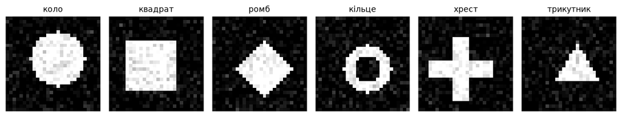

```
шість класів, по 120 прикладів кожного в навчальній вибірці
```

```python
import matplotlib.pyplot as plt

figure, axes = plt.subplots(1, 6, figsize=(11, 2))
for kind in range(6):
    # перші шість зображень датасету — саме по одному на кожен клас
    axes[kind].imshow(train_x[kind, 0], cmap="gray")
    axes[kind].set_title(SHAPE_NAMES[kind], fontsize=10)
    axes[kind].axis("off")
plt.tight_layout()
plt.show()
print("шість класів, по", len(train_y) // 6, "прикладів кожного в навчальній вибірці")
```

## 2 · Мережа з блоків

Блок — це три кроки: згортка шукає прикмети, `ReLU` прибирає відʼємні відгуки, пулінг удвічі зменшує карту. Опишемо блок один раз функцією й складемо з нього тіло мережі.

Голова — `Flatten` і два повнозвʼязні шари. Число 288 у першому з них ми зараз порахуємо руками, а поки просто впишемо.

```python
def conv_block(in_channels, out_channels):
    """Один типовий блок: Conv → ReLU → Pool. Порядок саме такий — див. розділ 2 лекції."""
    return nn.Sequential(
        nn.Conv2d(in_channels, out_channels, kernel_size=3, padding=1),
        nn.ReLU(),
        nn.MaxPool2d(2),
    )


class ShapeNet(nn.Module):
    """Три блоки з подвоєнням каналів і голова з Flatten."""

    def __init__(self):
        super().__init__()
        self.body = nn.Sequential(
            conv_block(1, 8),      # 1×28×28  →  8×14×14
            conv_block(8, 16),     # 8×14×14  → 16×7×7
            conv_block(16, 32),    # 16×7×7   → 32×3×3
        )
        self.head = nn.Sequential(
            nn.Flatten(),
            nn.Linear(32 * 3 * 3, 64),
            nn.ReLU(),
            nn.Linear(64, 6),
        )

    def forward(self, x):
        return self.head(self.body(x))


torch.manual_seed(0)
net = ShapeNet()
print(net)
print()
print("параметрів усього:", sum(p.numel() for p in net.parameters()))
```

```
ShapeNet(
  (body): Sequential(
    (0): Sequential(
      (0): Conv2d(1, 8, kernel_size=(3, 3), stride=(1, 1), padding=(1, 1))
      (1): ReLU()
      (2): MaxPool2d(kernel_size=2, stride=2, padding=0, dilation=1, ceil_mode=False)
    )
    (1): Sequential(
      (0): Conv2d(8, 16, kernel_size=(3, 3), stride=(1, 1), padding=(1, 1))
      (1): ReLU()
      (2): MaxPool2d(kernel_size=2, stride=2, padding=0, dilation=1, ceil_mode=False)
    )
    (2): Sequential(
      (0): Conv2d(16, 32, kernel_size=(3, 3), stride=(1, 1), padding=(1, 1))
      (1): ReLU()
      (2): MaxPool2d(kernel_size=2, stride=2, padding=0, dilation=1, ceil_mode=False)
    )
  )
  (head): Sequential(
    (0): Flatten(start_dim=1, end_dim=-1)
    (1): Linear(in_features=288, out_features=64, bias=True)
    (2): ReLU()
    (3): Linear(in_features=64, out_features=6, bias=True)
  )
)

параметрів усього: 24774
```

## 3 · Наскрізна таблиця форм: спершу рукою

Тепер найважливіша навичка теми. Порахуємо форму на виході кожного шару **без PyTorch**, за двома правилами з лекції:

- згортка 3×3 з `padding=1` і `stride=1` розмір **не міняє**;
- пулінг 2×2 з кроком 2 **ділить розмір на два**, дробова частина відкидається.

Функція нижче — це буквально ці два правила, записані кодом.

```python
def shapes_by_hand(input_side=28):
    """Рахує форми наскрізь за правилами з лекції. Повертає список (назва, канали, сторона)."""
    side = input_side
    channels = 1
    steps = [("вхід", channels, side)]

    # тіло: три блоки з подвоєнням каналів
    for out_channels in (8, 16, 32):
        # згортка 3×3 з padding=1 лишає сторону такою ж, міняє лише кількість каналів
        channels = out_channels
        steps.append(("Conv %d→%d" % (steps[-1][1], channels), channels, side))
        steps.append(("ReLU", channels, side))
        # пулінг 2×2 з кроком 2 ділить сторону навпіл, дробову частину відкидаємо
        side = side // 2
        steps.append(("MaxPool 2", channels, side))

    flat = channels * side * side
    steps.append(("Flatten", flat, 1))
    steps.append(("Linear %d→64" % flat, 64, 1))
    steps.append(("ReLU", 64, 1))
    steps.append(("Linear 64→6", 6, 1))
    return steps


hand_shapes = shapes_by_hand(28)

print("%-16s %-14s %10s" % ("шар", "вихід", "чисел"))
print("-" * 44)
for name, channels, side in hand_shapes:
    shape_text = "%d×%d×%d" % (channels, side, side) if side > 1 else str(channels)
    print("%-16s %-14s %10d" % (name, shape_text, channels * side * side))
```

```
шар              вихід               чисел
--------------------------------------------
вхід             1×28×28               784
Conv 1→8         8×28×28              6272
ReLU             8×28×28              6272
MaxPool 2        8×14×14              1568
Conv 8→16        16×14×14             3136
ReLU             16×14×14             3136
MaxPool 2        16×7×7                784
Conv 16→32       32×7×7               1568
ReLU             32×7×7               1568
MaxPool 2        32×3×3                288
Flatten          288                   288
Linear 288→64    64                     64
ReLU             64                     64
Linear 64→6      6                       6
```

## 4 · Та сама таблиця, але від PyTorch

Тепер перевіримо ручний рахунок. Найпростіший чесний спосіб — **хуки**: попросимо кожен шар повідомити форму свого виходу, коли крізь нього проходить зображення. Хук (`forward hook`) — це функція, яку PyTorch викликає після кожного шару.

```python
actual_shapes = []


def remember_shape(module, module_input, module_output):
    """Хук: записує імʼя шару й форму того, що він видав."""
    actual_shapes.append((type(module).__name__, tuple(module_output.shape)))


# вішаємо хук на кожен «листовий» шар — тобто на той, усередині якого вже немає інших
handles = []
for module in net.modules():
    if len(list(module.children())) == 0:
        handles.append(module.register_forward_hook(remember_shape))

with torch.no_grad():
    net(train_x[:1])                  # одне зображення крізь усю мережу

for handle in handles:                # хуки треба знімати, інакше вони спрацюють і далі
    handle.remove()

print("%-14s %-22s %10s" % ("шар", "фактична форма", "чисел"))
print("-" * 50)
for name, shape in actual_shapes:
    numbers = 1
    for dimension in shape:
        numbers *= dimension
    print("%-14s %-22s %10d" % (name, shape, numbers))
```

```
шар            фактична форма              чисел
--------------------------------------------------
Conv2d         (1, 8, 28, 28)               6272
ReLU           (1, 8, 28, 28)               6272
MaxPool2d      (1, 8, 14, 14)               1568
Conv2d         (1, 16, 14, 14)              3136
ReLU           (1, 16, 14, 14)              3136
MaxPool2d      (1, 16, 7, 7)                 784
Conv2d         (1, 32, 7, 7)                1568
ReLU           (1, 32, 7, 7)                1568
MaxPool2d      (1, 32, 3, 3)                 288
Flatten        (1, 288)                      288
Linear         (1, 64)                        64
ReLU           (1, 64)                        64
Linear         (1, 6)                          6
```

Тепер головне: **звірка**. Ручний рахунок дав список форм, хуки дали свій — вони мусять збігтися до останнього числа. Порівнюємо кількість чисел на виході кожного шару.

```python
hand_counts = [channels * side * side for _, channels, side in hand_shapes[1:]]   # без входу
actual_counts = []
for _, shape in actual_shapes:
    numbers = 1
    for dimension in shape:
        numbers *= dimension
    actual_counts.append(numbers)

print("%-16s %12s %12s   %s" % ("шар", "рукою", "PyTorch", "збіг"))
print("-" * 52)
for i, (name, _, _) in enumerate(hand_shapes[1:]):
    same = "так" if hand_counts[i] == actual_counts[i] else "НІ"
    print("%-16s %12d %12d   %s" % (name, hand_counts[i], actual_counts[i], same))

assert hand_counts == actual_counts, "ручний рахунок форм розійшовся з фактичним!"
print("\n✅ усі форми збіглися: ручний рахунок і PyTorch дають те саме")
```

```
шар                     рукою      PyTorch   збіг
----------------------------------------------------
Conv 1→8                 6272         6272   так
ReLU                     6272         6272   так
MaxPool 2                1568         1568   так
Conv 8→16                3136         3136   так
ReLU                     3136         3136   так
MaxPool 2                 784          784   так
Conv 16→32               1568         1568   так
ReLU                     1568         1568   так
MaxPool 2                 288          288   так
Flatten                   288          288   так
Linear 288→64              64           64   так
ReLU                       64           64   так
Linear 64→6                 6            6   так

✅ усі форми збіглися: ручний рахунок і PyTorch дають те саме
```

## 5 · Де живуть параметри

Тепер порахуємо ваги за формулами з лекції:

- згортка: `C_вх × C_вих × k × k + C_вих`;
- повнозвʼязний шар: `вхід × вихід + вихід`.

І одразу звіримо з `sum(p.numel())` — це та сама перевірка «наше проти бібліотечного», тільки для параметрів, а не для форм.

```python
def conv_params(in_channels, out_channels, kernel=3):
    """Ваг у згортці: ядро повторюється для кожної пари каналів, плюс зсув на вихід."""
    return in_channels * out_channels * kernel * kernel + out_channels


def linear_params(in_features, out_features):
    """Ваг у повнозвʼязному шарі: окрема вага на кожну пару чисел, плюс зсув на вихід."""
    return in_features * out_features + out_features


by_hand = [
    ("Conv 1→8",       conv_params(1, 8)),
    ("Conv 8→16",      conv_params(8, 16)),
    ("Conv 16→32",     conv_params(16, 32)),
    ("Linear 288→64",  linear_params(288, 64)),
    ("Linear 64→6",    linear_params(64, 6)),
]

# те саме від PyTorch: беремо кожен шар, у якого взагалі є параметри
from_torch = []
for name, module in net.named_modules():
    count = sum(p.numel() for p in module.parameters(recurse=False))
    if count:
        from_torch.append((name, count))

total = sum(count for _, count in by_hand)
print("%-16s %10s %10s %8s" % ("шар", "рукою", "PyTorch", "частка"))
print("-" * 48)
for (hand_name, hand_count), (torch_name, torch_count) in zip(by_hand, from_torch):
    print("%-16s %10d %10d %7.1f %%"
          % (hand_name, hand_count, torch_count, 100 * hand_count / total))
print("-" * 48)
print("%-16s %10d %10d" % ("усього", total, sum(p.numel() for p in net.parameters())))

assert [c for _, c in by_hand] == [c for _, c in from_torch], "параметри розійшлися!"
print("\n✅ ручний рахунок параметрів збігся з sum(p.numel()) для кожного шару")
```

```
шар                   рукою    PyTorch   частка
------------------------------------------------
Conv 1→8                 80         80     0.3 %
Conv 8→16              1168       1168     4.7 %
Conv 16→32             4640       4640    18.7 %
Linear 288→64         18496      18496    74.7 %
Linear 64→6             390        390     1.6 %
------------------------------------------------
усього                24774      24774

✅ ручний рахунок параметрів збігся з sum(p.numel()) для кожного шару
```

Прочитай колонку «частка» уважно — це і є головне відкриття теми. Тепер зведемо її в два числа: скільки ваг у тілі (три згортки) і скільки в голові.

```python
conv_total = sum(count for name, count in by_hand if name.startswith("Conv"))
head_total = sum(count for name, count in by_hand if name.startswith("Linear"))
first_linear = by_hand[3][1]

print("усі три згортки : %6d  — %.1f %%" % (conv_total, 100 * conv_total / total))
print("уся голова      : %6d  — %.1f %%" % (head_total, 100 * head_total / total))
print("перший Linear   : %6d  — %.1f %%" % (first_linear, 100 * first_linear / total))
print()
print("Три чверті ваг мережі сидять в одному шарі, який не бачить зображення,")
print("а лише множить розпластаний стовпчик на матрицю.")
```

```
усі три згортки :   5888  — 23.8 %
уся голова      :  18886  — 76.2 %
перший Linear   :  18496  — 74.7 %

Три чверті ваг мережі сидять в одному шарі, який не бачить зображення,
а лише множить розпластаний стовпчик на матрицю.
```

## 6 · Де живе памʼять

А тепер той самий розріз, але для **активацій** — чисел, які кожен шар видає й які зворотне поширення мусить памʼятати. Порахуємо їх у кілобайтах при `float32` (4 байти на число) і поставимо поруч із вагами того самого шару.

```python
BYTES_PER_NUMBER = 4          # float32

# беремо форми з хуків і залишаємо тільки шари, які справді щось міняють
rows = []
weights_by_layer = {"Conv2d": [80, 1168, 4640], "Linear": [18496, 390]}
conv_seen, linear_seen = 0, 0
for name, shape in actual_shapes:
    numbers = 1
    for dimension in shape:
        numbers *= dimension
    if name == "Conv2d":
        weight = weights_by_layer["Conv2d"][conv_seen]; conv_seen += 1
    elif name == "Linear":
        weight = weights_by_layer["Linear"][linear_seen]; linear_seen += 1
    else:
        weight = 0
    # ReLU і Flatten не створюють нової карти — це той самий тензор, тож памʼяті не додають
    if name not in ("ReLU", "Flatten"):
        rows.append((name, numbers, weight))

print("%-12s %10s %12s %10s" % ("шар", "чисел", "активації", "ваг"))
print("-" * 48)
for name, numbers, weight in rows:
    print("%-12s %10d %9.1f КБ %10d"
          % (name, numbers, numbers * BYTES_PER_NUMBER / 1024, weight))

peak_activation = max(rows, key=lambda row: row[1])
peak_weights = max(rows, key=lambda row: row[2])
print("-" * 48)
print("пік активацій:", peak_activation[0], "—", peak_activation[1], "чисел,",
      peak_activation[2], "ваг")
print("пік ваг      :", peak_weights[0], "—", peak_weights[1], "чисел,",
      peak_weights[2], "ваг")
```

```
шар               чисел    активації        ваг
------------------------------------------------
Conv2d             6272      24.5 КБ         80
MaxPool2d          1568       6.1 КБ          0
Conv2d             3136      12.2 КБ       1168
MaxPool2d           784       3.1 КБ          0
Conv2d             1568       6.1 КБ       4640
MaxPool2d           288       1.1 КБ          0
Linear               64       0.2 КБ      18496
Linear                6       0.0 КБ        390
------------------------------------------------
пік активацій: Conv2d — 6272 чисел, 80 ваг
пік ваг      : Linear — 64 чисел, 18496 ваг
```

Два максимуми стоять у **різних кінцях** мережі. Тепер порахуємо, що це означає для відеокарти: ваги від батча не залежать взагалі, активації ростуть пропорційно.

```python
activations_per_image = sum(numbers for _, numbers, _ in rows)
weights_megabytes = total * BYTES_PER_NUMBER / 1024 / 1024

print("активацій на одне зображення:", activations_per_image, "чисел")
print("ваги моделі: %.2f МБ (не залежать від батча)\n" % weights_megabytes)
print("%8s %14s" % ("батч", "активації"))
for batch in (1, 8, 64, 256):
    megabytes = activations_per_image * batch * BYTES_PER_NUMBER / 1024 / 1024
    print("%8d %11.2f МБ" % (batch, megabytes))
```

```
активацій на одне зображення: 13686 чисел
ваги моделі: 0.09 МБ (не залежать від батча)

    батч      активації
       1        0.05 МБ
       8        0.42 МБ
      64        3.34 МБ
     256       13.37 МБ
```

## 7 · Навчання

Одне навчання на весь зошит — шість епох на 720 прикладах. Цього досить, щоб мережа навчилась розрізняти шість фігур; нам тут важлива не рекордна точність, а те, що зібрана з блоків конструкція справді працює.

```python
def accuracy(model, images, labels):
    """Частка правильних відповідей; градієнти тут не потрібні, тому no_grad."""
    with torch.no_grad():
        predicted = model(images).argmax(dim=1)
    return (predicted == labels).float().mean().item()


torch.manual_seed(0)
optimizer = torch.optim.Adam(net.parameters(), lr=3e-3)
loss_function = nn.CrossEntropyLoss()
BATCH = 32

started = time.time()
for epoch in range(6):
    order = torch.randperm(len(train_x))          # перемішуємо порядок кожної епохи
    for start in range(0, len(train_x), BATCH):
        batch_index = order[start:start + BATCH]
        optimizer.zero_grad()
        loss = loss_function(net(train_x[batch_index]), train_y[batch_index])
        loss.backward()
        optimizer.step()
    print("епоха %d  втрата %.3f  точність на тесті %.3f"
          % (epoch + 1, loss.item(), accuracy(net, test_x, test_y)))

print("\nнавчання зайняло %.1f с" % (time.time() - started))
```

```
епоха 1  втрата 1.471  точність на тесті 0.532
```

```
епоха 2  втрата 0.278  точність на тесті 0.690
```

```
епоха 3  втрата 0.094  точність на тесті 0.983
```

```
епоха 4  втрата 0.005  точність на тесті 0.995
```

```
епоха 5  втрата 0.006  точність на тесті 1.000
```

```
епоха 6  втрата 0.004  точність на тесті 1.000

навчання зайняло 28.4 с
```

## 8 · Дослід із розміром входу

Тепер найцікавіший дослід зошита. Подамо на навчену мережу зображення **іншого розміру** — 40×40 замість 28×28 — і подивимось на справжню помилку PyTorch. Клітинка нижче **навмисно падає**: це і є результат, який треба побачити на власні очі.

```python
bigger_image = torch.zeros(1, 1, 40, 40)

with torch.no_grad():
    body_output = net.body(bigger_image)
print("тіло відпрацювало нормально, карта на виході:", tuple(body_output.shape))
print("Flatten дасть", body_output.numel(), "чисел, а Linear чекає 288")
print("\nа тепер той самий тензор крізь усю мережу:")
net(bigger_image)
```

```
тіло відпрацювало нормально, карта на виході: (1, 32, 5, 5)
Flatten дасть 800 чисел, а Linear чекає 288

а тепер той самий тензор крізь усю мережу:
```

[output not shown]

[output cut: 17 more lines]

[output not shown]

Помилка каже все прямо: `mat1 and mat2 shapes cannot be multiplied (1x800 and 288x64)`. Згортки відпрацювали бездоганно — упав саме повнозвʼязний шар, бо форма його матриці зафіксована при створенні мережі.

Тепер та сама мережа, але з головою на глобальному усередненні.

```python
class ShapeNetGAP(nn.Module):
    """Те саме тіло, але голова — глобальне усереднення замість Flatten."""

    def __init__(self):
        super().__init__()
        self.body = nn.Sequential(conv_block(1, 8), conv_block(8, 16), conv_block(16, 32))
        self.head = nn.Sequential(
            nn.AdaptiveAvgPool2d(1),      # від кожного каналу лишається одне число
            nn.Flatten(),
            nn.Linear(32, 6),
        )

    def forward(self, x):
        return self.head(self.body(x))


torch.manual_seed(0)
gap_net = ShapeNetGAP()

print("%8s %14s %14s %10s" % ("сторона", "карта тіла", "у Linear", "вихід"))
print("-" * 50)
for side in (20, 28, 40, 64):
    sample = torch.zeros(1, 1, side, side)
    with torch.no_grad():
        body_map = gap_net.body(sample)
        result = gap_net(sample)
    print("%8d %14s %14d %10s"
          % (side, tuple(body_map.shape)[1:], body_map.shape[1], tuple(result.shape)))

print()
print("параметрів у Flatten-мережі:", sum(p.numel() for p in net.parameters()))
print("параметрів у GAP-мережі    :", sum(p.numel() for p in gap_net.parameters()))
```

```
 сторона     карта тіла       у Linear      вихід
--------------------------------------------------
      20     (32, 2, 2)             32     (1, 6)
      28     (32, 3, 3)             32     (1, 6)
      40     (32, 5, 5)             32     (1, 6)
```

```
      64     (32, 8, 8)             32     (1, 6)

параметрів у Flatten-мережі: 24774
параметрів у GAP-мережі    : 6086
```

Колонка «у Linear» не змінюється: скільки б клітинок не було в каналі, середнє від них — одне число, а каналів завжди 32. Саме тому GAP-мережа приймає будь-який розмір входу. Заразом вона схудла вчетверо.

## 9 · Рецептивне поле: формула проти виміру

Рецептивне поле рахується двома числами наскрізь:

- `r_нове = r_старе + (k − 1) × j_старе` — сторона квадрата на вхідному зображенні;
- `j_нове = j_старе × s` — на скільки вхідних пікселів зсувається вікно між сусідами.

Спершу формула.

```python
def receptive_field(layers):
    """Наростаючий рахунок r і j по шарах. layers — список (назва, ядро, крок)."""
    r, j = 1, 1
    table = [("вхід", r, j)]
    for name, kernel, stride in layers:
        r = r + (kernel - 1) * j
        j = j * stride
        table.append((name, r, j))
    return table


body_layers = [
    ("Conv 3×3", 3, 1), ("MaxPool 2", 2, 2),
    ("Conv 3×3", 3, 1), ("MaxPool 2", 2, 2),
    ("Conv 3×3", 3, 1),
]

print("%-12s %6s %6s" % ("шар", "r", "j"))
print("-" * 26)
for name, r, j in receptive_field(body_layers):
    print("%-12s %6d %6d" % (name, r, j))

field_by_formula = receptive_field(body_layers)[-1][1]
print("\nодин нейрон останньої згортки бачить квадрат %d×%d на вході"
      % (field_by_formula, field_by_formula))
```

```
шар               r      j
--------------------------
вхід              1      1
Conv 3×3          3      1
MaxPool 2         4      2
Conv 3×3          8      2
MaxPool 2        10      4
Conv 3×3         18      4

один нейрон останньої згортки бачить квадрат 18×18 на вході
```

А тепер **вимір**. Візьмемо один нейрон останньої згортки й перевіримо перебором, які саме вхідні пікселі на нього впливають: зсунемо кожен піксель по черзі й подивимось, чи змінився вихід.

Одна тонкість. Рецептивне поле — властивість **геометрії** мережі, а не її ваг: воно не залежить від того, які числа вивчились. Але `ReLU` обнуляє частину шляхів, і через випадково мертвий нейрон вимір показав би менше, ніж є насправді. Тому міряємо на копії тіла **без нелінійності** — форми й кроки в неї ті самі.

```python
# те саме тіло, але без ReLU: геометрія та сама, жоден шлях не гине на нулі
geometry_only = nn.Sequential(
    net.body[0][0], nn.MaxPool2d(2),
    net.body[1][0], nn.MaxPool2d(2),
    net.body[2][0],
)

base_image = torch.randn(1, 1, 28, 28)

# збираємо батч: перше зображення без змін, далі 784 копії, у кожній зсунуто один піксель
probes = base_image.repeat(28 * 28 + 1, 1, 1, 1)
for pixel in range(28 * 28):
    probes[pixel + 1, 0, pixel // 28, pixel % 28] += 1.0

with torch.no_grad():
    outputs = geometry_only(probes)

# дивимось на центральний нейрон карти 32×7×7: канал 0, позиція (3, 3)
watched = outputs[:, 0, 3, 3]
changed = (watched[1:] - watched[0]).abs() > 1e-6
mask = changed.reshape(28, 28)

rows_touched = mask.any(dim=1).nonzero().flatten()
cols_touched = mask.any(dim=0).nonzero().flatten()
height = int(rows_touched[-1] - rows_touched[0] + 1)
width = int(cols_touched[-1] - cols_touched[0] + 1)

print("пікселів, які впливають на цей нейрон:", int(mask.sum()))
print("вони лежать у рядках %d..%d і стовпцях %d..%d"
      % (rows_touched[0], rows_touched[-1], cols_touched[0], cols_touched[-1]))
print("тобто квадрат %d×%d" % (height, width))
print("формула передбачала  %d×%d" % (field_by_formula, field_by_formula))

assert height == field_by_formula and width == field_by_formula, \
    "вимір рецептивного поля розійшовся з формулою!"
print("\n✅ формула й вимір збіглися")
```

```
пікселів, які впливають на цей нейрон: 324
вони лежать у рядках 5..22 і стовпцях 5..22
тобто квадрат 18×18
формула передбачала  18×18

✅ формула й вимір збіглися
```

Порівняємо це з розміром фігури. Радіус у нашому генераторі — від 7 до 9, тобто діаметр від 14 до 18 пікселів. Рецептивне поле щойно-щойно покриває фігуру — і саме тому мережа взагалі здатна відрізнити коло від кільця.

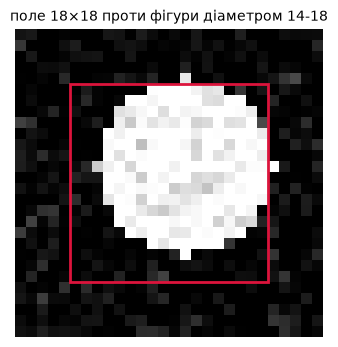

```
квадрат 18×18 на зображенні 28×28 — це 41 % його площі
```

```python
plt.figure(figsize=(4, 4))
plt.imshow(train_x[0, 0], cmap="gray")
# малюємо квадрат рецептивного поля навколо тієї самої точки, яку міряли
left, top = int(cols_touched[0]), int(rows_touched[0])
plt.gca().add_patch(plt.Rectangle((left - 0.5, top - 0.5), width, height,
                                  fill=False, edgecolor="crimson", linewidth=2))
plt.title("поле %d×%d проти фігури діаметром 14-18" % (height, width), fontsize=10)
plt.axis("off")
plt.show()
print("квадрат %d×%d на зображенні 28×28 — це %.0f %% його площі"
      % (height, width, 100 * height * width / (28 * 28)))
```

## 10 · Порядок ReLU і пулінгу

Останній дослід. У лекції ми стверджували: з max-пулінгом порядок `ReLU` і пулінгу не важить, а з avg-пулінгом — важить. Перевіримо це на тому самому шматку карти ознак, який показував інтерактив.

```python
feature_map = torch.tensor([[[
    [ 4., -3.,  1.,  6., -2.,  0.],
    [-5.,  2.,  7., -1.,  3., -4.],
    [ 1.,  8., -6.,  2., -3.,  5.],
    [ 3., -2.,  0.,  9., -7.,  1.],
    [-1.,  5.,  4., -3.,  2.,  6.],
    [ 2., -4.,  3.,  1.,  8., -5.],
]]])

relu = nn.ReLU()
max_pool = nn.MaxPool2d(2)
avg_pool = nn.AvgPool2d(2)

max_first_relu = max_pool(relu(feature_map))
max_first_pool = relu(max_pool(feature_map))
avg_first_relu = avg_pool(relu(feature_map))
avg_first_pool = relu(avg_pool(feature_map))

print("max-пулінг, ReLU спершу:\n", max_first_relu[0, 0].numpy())
print("max-пулінг, пулінг спершу:\n", max_first_pool[0, 0].numpy())
print("однаково:", torch.equal(max_first_relu, max_first_pool))
print()
print("avg-пулінг, ReLU спершу:\n", avg_first_relu[0, 0].numpy())
print("avg-пулінг, пулінг спершу:\n", avg_first_pool[0, 0].numpy())
print("однаково:", torch.equal(avg_first_relu, avg_first_pool))
print("найбільше розходження:",
      (avg_first_relu - avg_first_pool).abs().max().item())

assert torch.equal(max_first_relu, max_first_pool), "з максимумом порядок мав не важити!"
assert not torch.equal(avg_first_relu, avg_first_pool), "із середнім порядок мав важити!"
print("\n✅ з max-пулінгом порядок вільний, з avg-пулінгом — ні")
```

```
max-пулінг, ReLU спершу:
 [[4. 7. 3.]
 [8. 9. 5.]
 [5. 4. 8.]]
max-пулінг, пулінг спершу:
 [[4. 7. 3.]
 [8. 9. 5.]
 [5. 4. 8.]]
```

```
однаково: True

avg-пулінг, ReLU спершу:
 [[1.5  3.5  0.75]
 [3.   2.75 1.5 ]
 [1.75 2.   4.  ]]
avg-пулінг, пулінг спершу:
 [[0.   3.25 0.  ]
 [2.5  1.25 0.  ]
 [0.5  1.25 2.75]]
однаково: False
найбільше розходження: 1.5

✅ з max-пулінгом порядок вільний, з avg-пулінгом — ні
```

## Що далі

Ти зібрав мережу з блоків, порахував рукою кожну її форму й кожну вагу, звірив усе з PyTorch і виміряв рецептивне поле замість того, щоб повірити формулі. Головні числа цього зошита:

- **74.7 %** ваг мережі — в одному шарі, першому `Linear`;
- **6 272** активації після першої згортки проти **64** після цього `Linear`;
- **18×18** — рецептивне поле останньої згортки при фігурі діаметром 14-18;
- **вчетверо** менша мережа з головою на глобальному усередненні, яка ще й приймає будь-який розмір входу.

Далі — домашнє завдання на три рівні. Найцікавіший третій: зібрати класифікатор під бюджет у 10 000 параметрів і **довести розрахунком**, що бюджет дотримано, ще до того як запускати код.